# Capstone Project: Customer Behaviour and Retention Analytics

Eliud Mule

2026-05-27

# Set Working Directory

```r
  # setwd("C:/Users/ADMIN/OneDrive/Desktop/Eliud/R")
```

## **Phase1:Data Understanding and Cleaning**

```r
# Load necessary libraries
library(dplyr)
library(tidyverse)
library(rio)
library(psych)
# Load the dataset
data <- read.csv("customerData.csv")
head(data)
```

```
  customer_id age gender   education employment_status annual_income
1           1  43   Male High School          Employed      36939.42
2           2  36   Male     Diploma     Self-Employed      40943.14
3           3  45   Male         PhD          Employed      81559.11
4           4  56   Male    Bachelor          Employed      53075.37
5           5  35 Female     Diploma          Employed      46630.28
6           6  35   Male    Bachelor          Employed      45729.72
  marital_status number_of_children   region annual_spending credit_score
1        Married                  3 Suburban         9034.57          439
2        Married                  0 Suburban         7949.83          446
3        Married                  2    Urban        34276.90          527
4         Single                  0    Urban        19219.62          498
5        Married                  1    Rural        10544.99          488
6         Single                  0    Rural        13366.91          442
  loyalty_years payment_type online_shopper churn
1            19   Debit Card             No    No
2             9 Mobile Money             No    No
3            18  Credit Card            Yes    No
4            35  Credit Card             No    No
5            15   Debit Card             No    No
6            16   Debit Card            Yes    No
```

### **Data Structure and Summary Statistics**

```r
  str(data)
```

```
'data.frame':   10000 obs. of  15 variables:
 $ customer_id       : int  1 2 3 4 5 6 7 8 9 10 ...
 $ age               : int  43 36 45 56 35 35 56 47 32 44 ...
 $ gender            : chr  "Male" "Male" "Male" "Male" ...
 $ education         : chr  "High School" "Diploma" "PhD" "Bachelor" ...
 $ employment_status : chr  "Employed" "Self-Employed" "Employed" "Employed" ...
 $ annual_income     : num  36939 40943 81559 53075 46630 ...
 $ marital_status    : chr  "Married" "Married" "Married" "Single" ...
 $ number_of_children: int  3 0 2 0 1 0 5 1 1 2 ...
 $ region            : chr  "Suburban" "Suburban" "Urban" "Urban" ...
 $ annual_spending   : num  9035 7950 34277 19220 10545 ...
 $ credit_score      : int  439 446 527 498 488 442 515 383 432 379 ...
 $ loyalty_years     : int  19 9 18 35 15 16 36 22 7 18 ...
 $ payment_type      : chr  "Debit Card" "Mobile Money" "Credit Card" "Credit Card" ...
 $ online_shopper    : chr  "No" "No" "Yes" "No" ...
 $ churn             : chr  "No" "No" "No" "No" ...
```

```r
  describe(data)
```

```
                   vars     n     mean       sd   median  trimmed      mad  min
customer_id           1 10000  5000.50  2886.90  5000.50  5000.50  3706.50    1
age                   2 10000    37.73    11.45    37.00    37.48    11.86   18
gender*               3 10000     1.48     0.50     1.00     1.47     0.00    1
education*            4 10000     2.39     1.20     2.00     2.30     1.48    1
employment_status*    5 10000     1.70     1.00     1.00     1.50     0.00    1
annual_income         6 10000 43632.35 23346.70 42386.12 42858.75 24540.74 5000
marital_status*       7 10000     1.38     0.48     1.00     1.34     0.00    1
number_of_children    8 10000     1.03     1.42     0.00     0.76     0.00    0
region*               9 10000     2.30     0.78     3.00     2.37     0.00    1
annual_spending      10 10000 15281.57  9541.26 14169.99 14585.07  9582.87 1000
credit_score         11 10000   461.78    59.55   460.00   460.84    60.79  300
loyalty_years        12 10000    15.64    11.17    15.00    14.97    11.86    0
payment_type*        13 10000     2.44     0.92     2.00     2.43     1.48    1
online_shopper*      14 10000     1.53     0.50     2.00     1.54     0.00    1
churn*               15 10000     1.10     0.30     1.00     1.00     0.00    1
                         max     range  skew kurtosis     se
customer_id         10000.00   9999.00  0.00    -1.20  28.87
age                    70.00     52.00  0.22    -0.43   0.11
gender*                 2.00      1.00  0.09    -1.99   0.00
education*              5.00      4.00  0.43    -0.82   0.01
employment_status*      4.00      3.00  1.22     0.18   0.01
annual_income      123314.91 118314.91  0.31    -0.36 233.47
marital_status*         2.00      1.00  0.51    -1.74   0.00
number_of_children      5.00      5.00  1.32     0.78   0.01
region*                 3.00      2.00 -0.58    -1.15   0.01
annual_spending     59228.89  58228.89  0.69     0.28  95.41
credit_score          693.00    393.00  0.15    -0.16   0.60
loyalty_years          52.00     52.00  0.42    -0.47   0.11
payment_type*           4.00      3.00  0.16    -0.80   0.01
online_shopper*         2.00      1.00 -0.14    -1.98   0.00
churn*                  2.00      1.00  2.68     5.17   0.00
```

### **Checking for Missing Values, Duplicates, and Data Inconsistencies**

```r
# Check for missing values
missing_values <- colSums(is.na(data))
print(missing_values)
```

```
       customer_id                age             gender          education
                 0                  0                  0                  0
 employment_status      annual_income     marital_status number_of_children
                 0                  0                  0                  0
            region    annual_spending       credit_score      loyalty_years
                 0                  0                  0                  0
      payment_type     online_shopper              churn
                 0                  0                  0
```

> There are no missing values in the dataset, which indicates that the data is complete and ready for analysis.

```r
# Check for duplicates
duplicates <- data[duplicated(data), ]
print(duplicates)
```

```
 [1] customer_id        age                gender             education
 [5] employment_status  annual_income      marital_status     number_of_children
 [9] region             annual_spending    credit_score       loyalty_years
[13] payment_type       online_shopper     churn
<0 rows> (or 0-length row.names)
```

> There are no duplicate records in the dataset, which ensures that each observation is unique and contributes to the analysis without redundancy.

```r
# Check for Data Inconsistencies
inconsistent_data <- data %>%
  filter(age < 18 | age > 100 | annual_spending < 0 |loyalty_years < 0 |gender =="male" |gender == "female" )
print(inconsistent_data)
```

```
 [1] customer_id        age                gender             education
 [5] employment_status  annual_income      marital_status     number_of_children
 [9] region             annual_spending    credit_score       loyalty_years
[13] payment_type       online_shopper     churn
<0 rows> (or 0-length row.names)
```

> There are no data inconsistencies in the dataset, which indicates that the data is clean and adheres to expected ranges and categories for the variables.

### **Detecting Outliers using Boxplot**

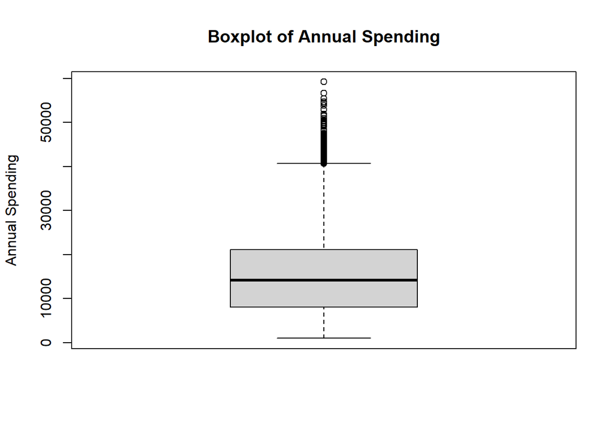

```r
# Boxplot for annual_spending
boxplot(data$annual_spending, main = "Boxplot of Annual Spending", ylab = "Annual Spending")
```

> The boxplot for annual spending reveals the presence of outliers, as indicated by the points that fall outside the whiskers of the boxplot.

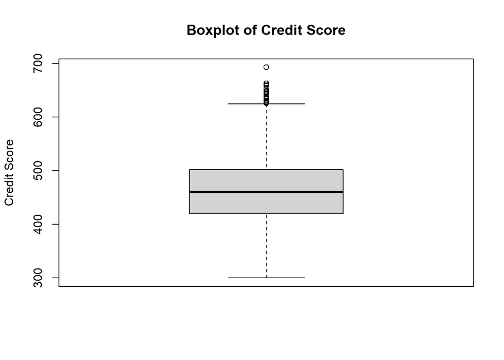

```r
# Boxplot for Credit Score
boxplot(data$credit_score, main = "Boxplot of Credit Score", ylab = "Credit Score")
```

> The boxplot for credit score also indicates the presence of outliers, as there are points that lie outside the whiskers of the boxplot.

### **Handling Outliers**

```r
# Applying IQR method to remove outliers from annual_spending
Q1 <- quantile(data$annual_spending, 0.25)
Q3 <- quantile(data$annual_spending, 0.75)
IQR <- Q3 - Q1

lower_bound <- Q1 - 1.5 * IQR
upper_bound <- Q3 + 1.5 * IQR
data_cleaned <- data %>%
  filter(annual_spending >= lower_bound & annual_spending <= upper_bound)
```

```r
# Applying IQR method to remove outliers from credit_score
Q1_cs <- quantile(data$credit_score, 0.25)
Q3_cs <- quantile(data$credit_score, 0.75)
IQR_cs <- Q3_cs - Q1_cs

lower_bound_cs <- Q1_cs - 1.5 * IQR_cs
upper_bound_cs <- Q3_cs + 1.5 * IQR_cs
data_cleaned <- data_cleaned %>%
  filter(credit_score >= lower_bound_cs & credit_score <= upper_bound_cs)
```

### **Visualize after removing outliers**

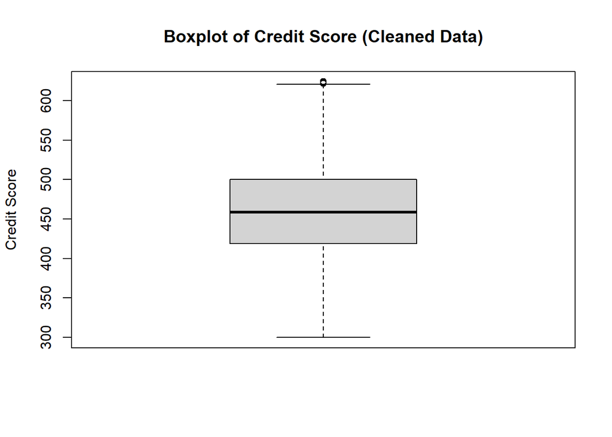

```r
boxplot(data_cleaned$credit_score, main = "Boxplot of Credit Score (Cleaned Data)", ylab = "Credit Score")
```

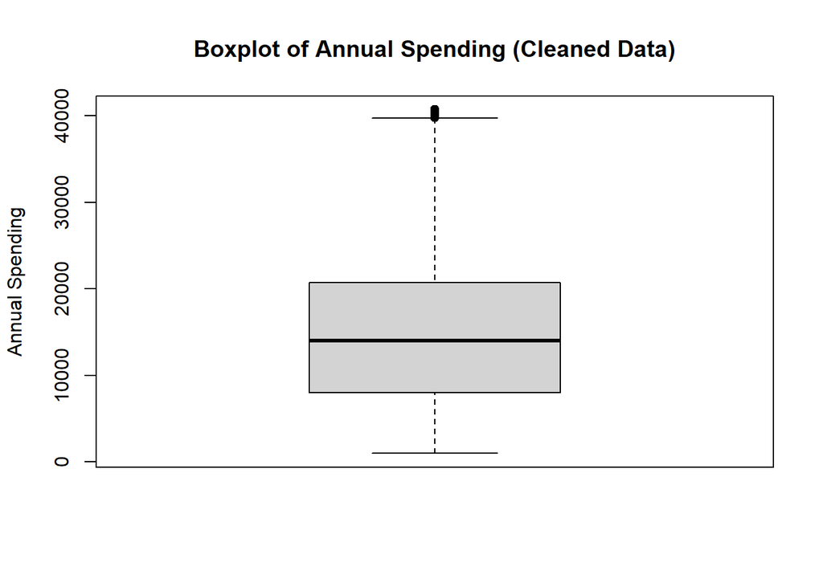

```r
# Boxplot of cleaned data
boxplot(data_cleaned$annual_spending, main = "Boxplot of Annual Spending (Cleaned Data)", ylab = "Annual Spending")
```

## **Phase 2: Preprocessing and Feature Engineering**

### **Feature Engineering**

```r
# Create  new features: Spending _to_income ratio,Customer Tenure,Financial_stability_score
data_cleaned <-data_cleaned %>%  mutate( spending_to_income_ratio = annual_spending / annual_income, customer_tenure = loyalty_years*12, financial_stability_score = credit_score / annual_income)
head(data_cleaned)
```

```
  customer_id age gender   education employment_status annual_income
1           1  43   Male High School          Employed      36939.42
2           2  36   Male     Diploma     Self-Employed      40943.14
3           3  45   Male         PhD          Employed      81559.11
4           4  56   Male    Bachelor          Employed      53075.37
5           5  35 Female     Diploma          Employed      46630.28
6           6  35   Male    Bachelor          Employed      45729.72
  marital_status number_of_children   region annual_spending credit_score
1        Married                  3 Suburban         9034.57          439
2        Married                  0 Suburban         7949.83          446
3        Married                  2    Urban        34276.90          527
4         Single                  0    Urban        19219.62          498
5        Married                  1    Rural        10544.99          488
6         Single                  0    Rural        13366.91          442
  loyalty_years payment_type online_shopper churn spending_to_income_ratio
1            19   Debit Card             No    No                0.2445780
2             9 Mobile Money             No    No                0.1941676
3            18  Credit Card            Yes    No                0.4202706
4            35  Credit Card             No    No                0.3621194
5            15   Debit Card             No    No                0.2261404
6            16   Debit Card            Yes    No                0.2923025
  customer_tenure financial_stability_score
1             228               0.011884323
2             108               0.010893156
3             216               0.006461571
4             420               0.009382883
5             180               0.010465303
6             192               0.009665487
```

### **Encoding Categorical Variables**

```r
# One-hot encoding for categorical variables
encoded_data <- model.matrix(~ . - 1, data = data_cleaned)

# Convert the encoded data to a data frame
encoded_data <- as.data.frame(encoded_data)
head(encoded_data)
```

```
  customer_id age genderFemale genderMale educationDiploma educationHigh School
1           1  43            0          1                0                    1
2           2  36            0          1                1                    0
3           3  45            0          1                0                    0
4           4  56            0          1                0                    0
5           5  35            1          0                1                    0
6           6  35            0          1                0                    0
  educationMaster educationPhD employment_statusSelf-Employed
1               0            0                              0
2               0            0                              1
3               0            1                              0
4               0            0                              0
5               0            0                              0
6               0            0                              0
  employment_statusStudent employment_statusUnemployed annual_income
```

[output cut: 34 more lines]

## **Phase 3: Exploratory Data Analysis (EDA)**

### **Univariate Analysis**

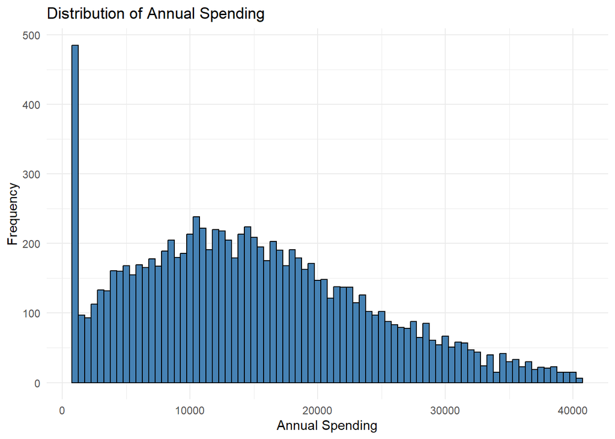

```r
# Histogram for annual_spending
ggplot(encoded_data, aes(x = annual_spending)) +
  geom_histogram(binwidth = 500, fill = "steelblue", color = "black") +
  labs(title = "Distribution of Annual Spending", x = "Annual Spending", y = "Frequency") +
  theme_minimal()
```

Interpretation: The histogram of annual spending shows a right-skewed distribution, indicating that most customers have lower annual spending, while a smaller number of customers have higher annual spending.

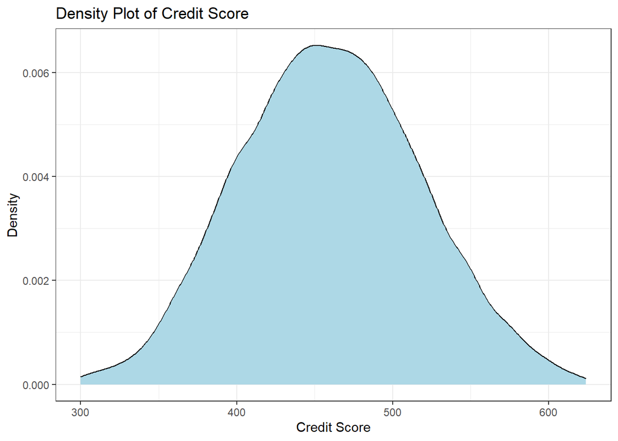

```r
# Density plot for credit_score
ggplot(encoded_data, aes(x = credit_score)) +
  geom_density(fill = "lightblue", color = "black") +
  labs(title = "Density Plot of Credit Score", x = "Credit Score", y = "Density") +
  theme_bw()
```

Interpretation: The density plot of credit score shows a unimodal distribution, with most customers having credit scores around the mean, and fewer customers having very low or very high credit scores.

```r
# Frequency table for annual_income
#table(encoded_data$annual_income)
#prop.table(table(encoded_data$annual_income))
```

### **Multivariate Analysis**

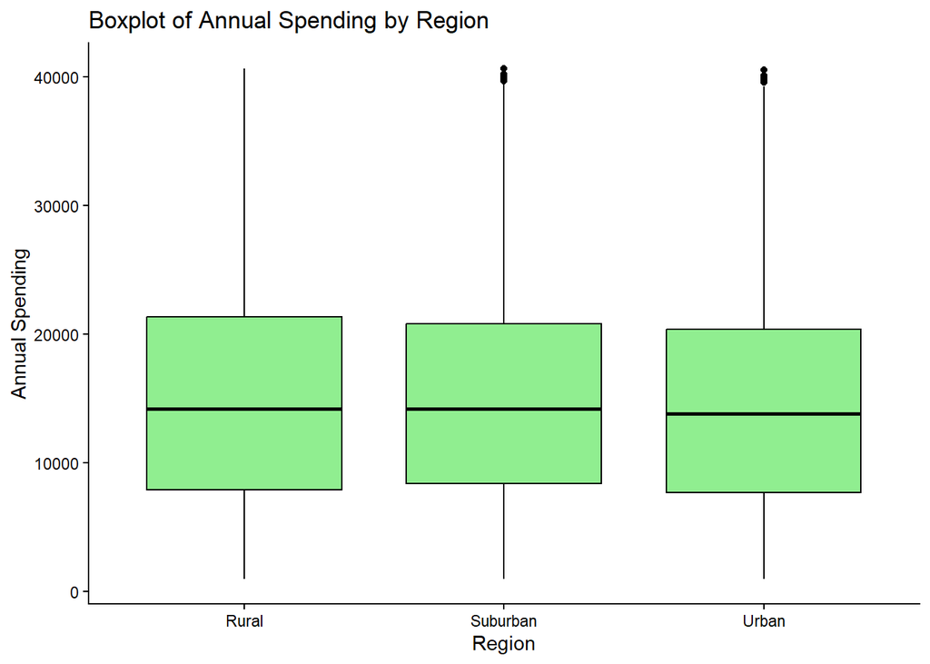

```r
# Boxplot of Spending by Region
ggplot(data_cleaned, aes(x = region, y = annual_spending)) +
  geom_boxplot(fill = "lightgreen", color = "black") +
  labs(title = "Boxplot of Annual Spending by Region", x = "Region", y = "Annual Spending") +
  theme_classic()
```

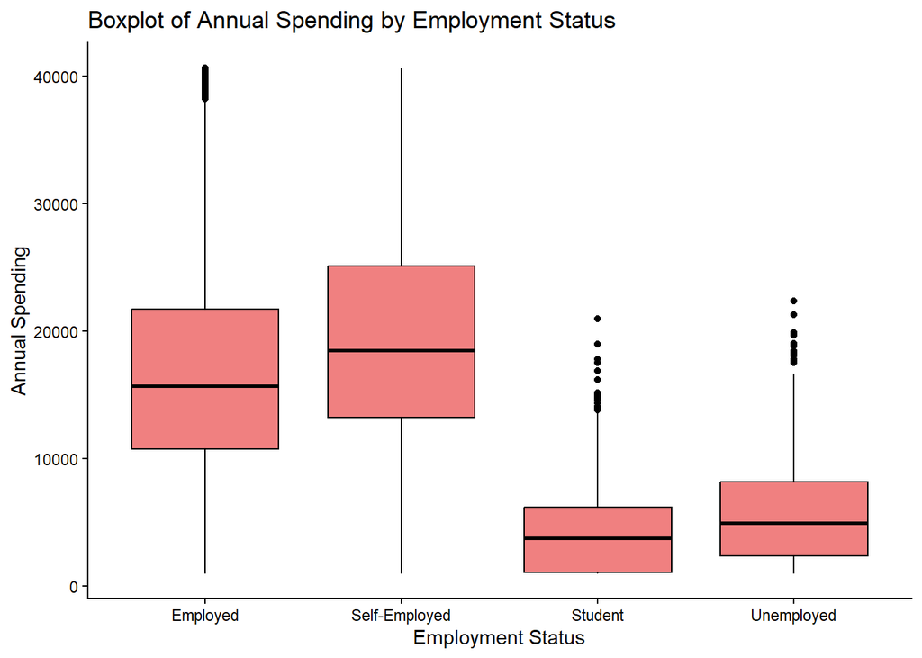

```r
# Boxplot of Spending by employment_status
ggplot(data_cleaned, aes(x = employment_status, y = annual_spending)) +
  geom_boxplot(fill = "lightcoral", color = "black") +
  labs(title = "Boxplot of Annual Spending by Employment Status", x = "Employment Status", y = "Annual Spending") +
  theme_classic()
```

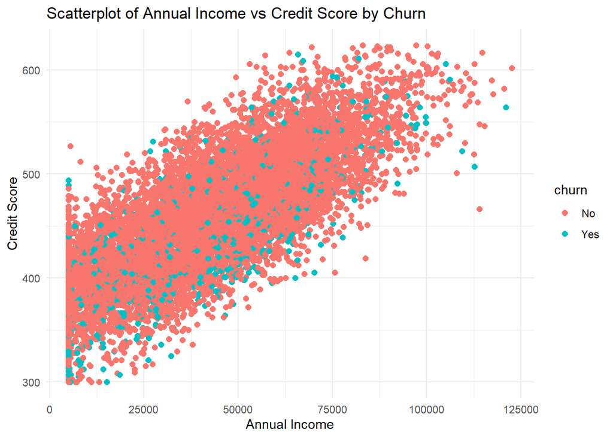

```r
#Scatterplot of income vs credit score by churn
ggplot(data_cleaned, aes(x = annual_income, y = credit_score, color = churn)) +
  geom_point(size = 2) +
  labs(title = "Scatterplot of Annual Income vs Credit Score by Churn", x = "Annual Income", y = "Credit Score") +
  theme_minimal()
```

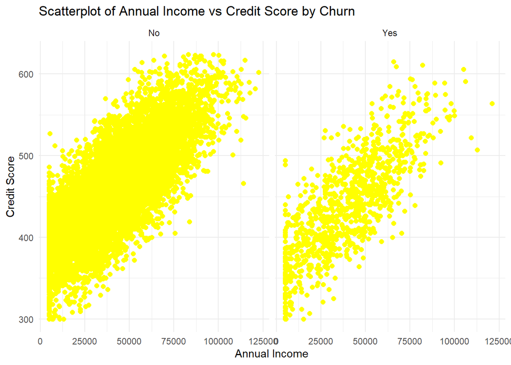

```r
#Scatterplot of income vs credit score by churn
ggplot(data_cleaned, aes(x = annual_income, y = credit_score, )) +
  geom_point(size = 2,color ="yellow") +
  facet_wrap(~churn) +
  labs(title = "Scatterplot of Annual Income vs Credit Score by Churn", x = "Annual Income", y = "Credit Score") +

  theme_minimal()
```

```r
# Correlation matrix for numerical variables
numeric_data <- data_cleaned %>%
  select_if(is.numeric)
cor_matrix <- cor(numeric_data, use = "complete.obs")
print(cor_matrix)
```

```
                           customer_id          age annual_income
customer_id                1.000000000 -0.009704517 -0.0038425507
age                       -0.009704517  1.000000000 -0.0110538281
annual_income             -0.003842551 -0.011053828  1.0000000000
number_of_children        -0.002927762  0.557208505 -0.0001300045
annual_spending           -0.004386163 -0.003118750  0.8262650612
credit_score              -0.020742182  0.377664676  0.7674681382
loyalty_years             -0.002680103  0.966786523 -0.0101777735
spending_to_income_ratio  -0.002176860  0.011493977 -0.1462322654
customer_tenure           -0.002680103  0.966786523 -0.0101777735
financial_stability_score  0.001316877  0.057221604 -0.7121258574
                          number_of_children annual_spending credit_score
customer_id                    -0.0029277623    -0.004386163  -0.02074218
age                             0.5572085054    -0.003118750   0.37766468
annual_income                  -0.0001300045     0.826265061   0.76746814
number_of_children              1.0000000000    -0.003968832   0.21194571
annual_spending                -0.0039688317     1.000000000   0.63398094
credit_score                    0.2119457147     0.633980935   1.00000000
loyalty_years                   0.5479081079    -0.002820720   0.36427631
spending_to_income_ratio       -0.0095231382     0.279847002  -0.11116109
customer_tenure                 0.5479081079    -0.002820720   0.36427631
financial_stability_score       0.0213009278    -0.590141385  -0.49412265
                          loyalty_years spending_to_income_ratio
customer_id                -0.002680103             -0.002176860
age                         0.966786523              0.011493977
annual_income              -0.010177773             -0.146232265
number_of_children          0.547908108             -0.009523138
annual_spending            -0.002820720              0.279847002
credit_score                0.364276312             -0.111161092
loyalty_years               1.000000000              0.011790271
spending_to_income_ratio    0.011790271              1.000000000
customer_tenure             1.000000000              0.011790271
financial_stability_score   0.052120571              0.238181454
                          customer_tenure financial_stability_score
customer_id                  -0.002680103               0.001316877
age                           0.966786523               0.057221604
annual_income                -0.010177773              -0.712125857
number_of_children            0.547908108               0.021300928
annual_spending              -0.002820720              -0.590141385
credit_score                  0.364276312              -0.494122654
loyalty_years                 1.000000000               0.052120571
spending_to_income_ratio      0.011790271               0.238181454
customer_tenure               1.000000000               0.052120571
financial_stability_score     0.052120571               1.000000000
```

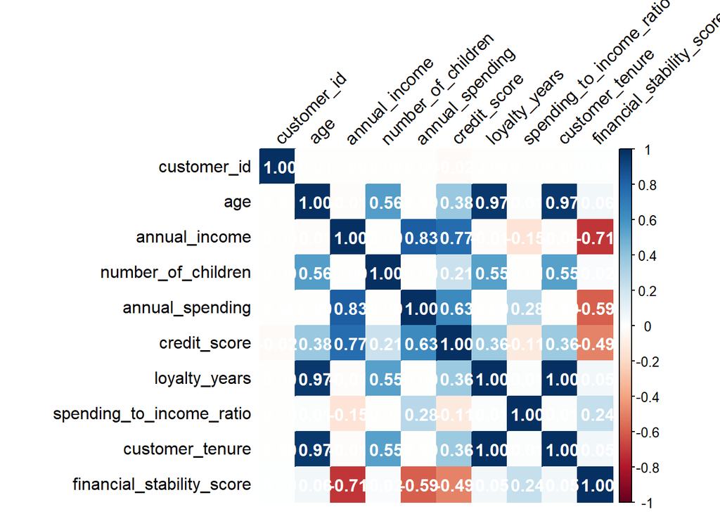

```r
# Heatmap of correlation matrix
library(corrplot)
corrplot(cor_matrix,
         #title = "Pairwise Correlation Plot",
         method = "color",
        # type = "upper",
         addCoef.col = "white",
         tl.col = "black",
         tl.srt = 45)
```

Interpretation: The correlation matrix and heatmap reveal several significant correlations among the numerical variables. Annual spending has a strong positive correlation with annual income (r = 0.83), indicating that customers with higher incomes tend to spend more annually. Additionally, there is a moderate positive correlation between credit score and annual spending (r = 0.63), suggesting that customers with higher spendings also tend to have better credit scores. However, there is a weak negative correlation between loyalty years and annual spending (r = -0.0028), indicating that customers who have been loyal for longer periods may spend slightly less annually. Overall, these correlations suggest that income and credit score are important factors influencing annual spending, while loyalty years have a less significant impact on spending behavior.

## **Phase 4: Descrriptive Statistics and Inference**

### **Summary Statistics for spending across groups**

```r
# Summary statistics for annual_spending by region
data_cleaned %>%
  group_by(region) %>%
  summarise(mean_spending = mean(annual_spending),
            median_spending = median(annual_spending),
            sd_spending = sd(annual_spending),
            IQR_spending = IQR(annual_spending))
```

```
# A tibble: 3 × 5
  region   mean_spending median_spending sd_spending IQR_spending
  <chr>            <dbl>           <dbl>       <dbl>        <dbl>
1 Rural           15047.          14210.       9120.       13465.
2 Suburban        15142.          14180.       8949.       12448.
3 Urban           14658.          13847.       8930.       12677.
```

```r
# Summary statistics for annual_spending by employment_status
data_cleaned %>%
  group_by(employment_status) %>%
  summarise(mean_spending = mean(annual_spending),
            median_spending = median(annual_spending),
            sd_spending = sd(annual_spending),
            IQR_spending = IQR(annual_spending))
```

```
# A tibble: 4 × 5
  employment_status mean_spending median_spending sd_spending IQR_spending
  <chr>                     <dbl>           <dbl>       <dbl>        <dbl>
1 Employed                 16733.          15708.       7997.       10980.
2 Self-Employed            19442.          18512.       8277.       11904.
3 Student                   4388.           3749.       3454.        5097.
4 Unemployed                5694.           4975.       4051.        5836.
```

```r
# Summary statistics for annual_spending by education_level
data_cleaned %>%
  group_by(education) %>%
  summarise(mean_spending = mean(annual_spending),
            median_spending = median(annual_spending),
            sd_spending = sd(annual_spending),
            IQR_spending = IQR(annual_spending))
```

```
# A tibble: 5 × 5
  education   mean_spending median_spending sd_spending IQR_spending
  <chr>               <dbl>           <dbl>       <dbl>        <dbl>
1 Bachelor           17319.          17636.       8716.       12383.
2 Diploma            12334.          12243.       6635.        9343.
3 High School         9724.           9475.       5465.        7760.
4 Master             21101.          21852.      10104.       14333.
5 PhD                23284.          24431.      11448.       17848.
```

### **Confidence Intervals**

```r
conf_int <- t.test(data_cleaned$annual_spending)
print(conf_int)
```

```
    One Sample t-test

data:  data_cleaned$annual_spending
t = 164.54, df = 9850, p-value < 2.2e-16
alternative hypothesis: true mean is not equal to 0
95 percent confidence interval:
 14703.63 15058.19
sample estimates:
mean of x
 14880.91
```

- The mean annual spending is estimated to be approximately 14880.91 with a 95% confidence interval ranging from 14703.63 to 15058.19. The interval does not include zero,indicating statistical significance at the 5% level. In addition, the confidence interval is relatively narrow, suggesting a precise estimate of the mean annual spending for the customer base. This information can be valuable for business decision-making and strategic planning related to customer spending behavior.

## **Phase 5: Hypothesis Testing**

### **Parametric Tests**

#### **Two-sample t-test**

##### **State the null and alternative hypotheses**

- Null Hypothesis (H0): There is no significant difference in mean annual spending between churned and non-churned customers.
- Alternative Hypothesis (H1): There is a significant difference in mean annual spending between churned and non-churned customers.

> Assumptions for the two-sample t-test and A: 1. Independence: The observations in each group (churned and non-churned) are independent of each other. 2. Normality: The annual spending variable is approximately normally distributed within each group. 3. Homogeneity of Variances: The variances of annual spending are equal across the two groups.

```r
# Two-sample t-test for annual_spending by churn
t_test_result <- t.test(annual_spending ~ churn, data = data_cleaned)
print(t_test_result)
```

```
    Welch Two Sample t-test

data:  annual_spending by churn
t = 4.3965, df = 1213.2, p-value = 1.196e-05
alternative hypothesis: true difference in means between group No and group Yes is not equal to 0
95 percent confidence interval:
  734.7357 1918.8948
sample estimates:
 mean in group No mean in group Yes
         15013.71          13686.90
```

The two-sample t-test results indicate that there is a statistically significant difference in mean annual spending between churned and non-churned customers (p-value = 0.00001196). The mean annual spending for non-churned customers is higher than that of churned customers, suggesting that customers who do not churn tend to spend more annually compared to those who do churn. This finding can provide valuable insights for customer retention strategies, as it highlights the importance of targeting non-churned customers who have higher spending potential.

#### **ANOVA with post-hoc Analysis**

> Assumptions for ANOVA: 1. Independence: The observations in each group (regions) are independent of each other. 2. Normality: The annual spending variable is approximately normally distributed within each group. 3. Homogeneity of Variances: The variances of annual spending are equal across the different regions.

##### **State the null and alternative hypotheses**

- Null Hypothesis (H0): There mean annual spendingis the same across different regions.
- Alternative Hypothesis (H1): At least one region has a different mean annual spending compared to the others.

```r
model_aov <- aov(annual_spending ~ region, data = data_cleaned)
summary(model_aov)
```

```
              Df    Sum Sq   Mean Sq F value Pr(>F)
region         2 5.001e+08 250050644   3.105 0.0449 *
Residuals   9848 7.932e+11  80542332
---
Signif. codes:  0 '***' 0.001 '**' 0.01 '*' 0.05 '.' 0.1 ' ' 1
```

The reults above with an F-value of 3.105 and a p-value of 0.045 indicate that there is a statistically significant difference in mean annual spending across different regions although small. Therefore, we reject the null hypothesis, suggesting that regional location does have a small significant impact on customers’ annual spending behavior in this dataset.

```r
# Effect size calculation (Eta Squared)
library(effectsize)
eta_squared_result <- eta_squared(model_aov)
print(eta_squared_result)
```

```
# Effect Size for ANOVA

Parameter |     Eta2 |       95% CI
-----------------------------------
region    | 6.30e-04 | [0.00, 1.00]

- One-sided CIs: upper bound fixed at [1.00].
```

The effectsize(Eta2) of 0.00063 indicates that only 0.063% of the variance in annual spending can be explained by the region variable, suggesting a very small effect size. This implies that while there is a statistically significant difference in mean annual spending across regions, the practical significance of this difference is minimal, and other factors may play a more substantial role in influencing customers’ annual spending behavior.

```r
# Post-hoc analysis using Tukey's HSD test
tukey_result <- TukeyHSD(model_aov)
print(tukey_result)
```

```
  Tukey multiple comparisons of means
    95% family-wise confidence level

Fit: aov(formula = annual_spending ~ region, data = data_cleaned)

$region
                     diff       lwr        upr     p adj
Suburban-Rural   94.51283 -515.2416 704.267238 0.9298237
Urban-Rural    -389.76071 -946.9582 167.436817 0.2290295
Urban-Suburban -484.27354 -975.4612   6.914155 0.0543216
```

From the Tukey’s HSD test results, we can see that there is no statistically significant difference in mean annual spending between any pair of regions, as all p-values are greater than 0.05. This suggests that while the ANOVA indicated a significant difference across regions, the post-hoc analysis does not identify any specific pairs of regions that differ significantly from each other in terms of annual spending. Therefore, we can conclude that regional location does not have a significant impact on customers’ annual spending behavior in this dataset when comparing specific regions to each other.

#### **Plot the post-hoc results**

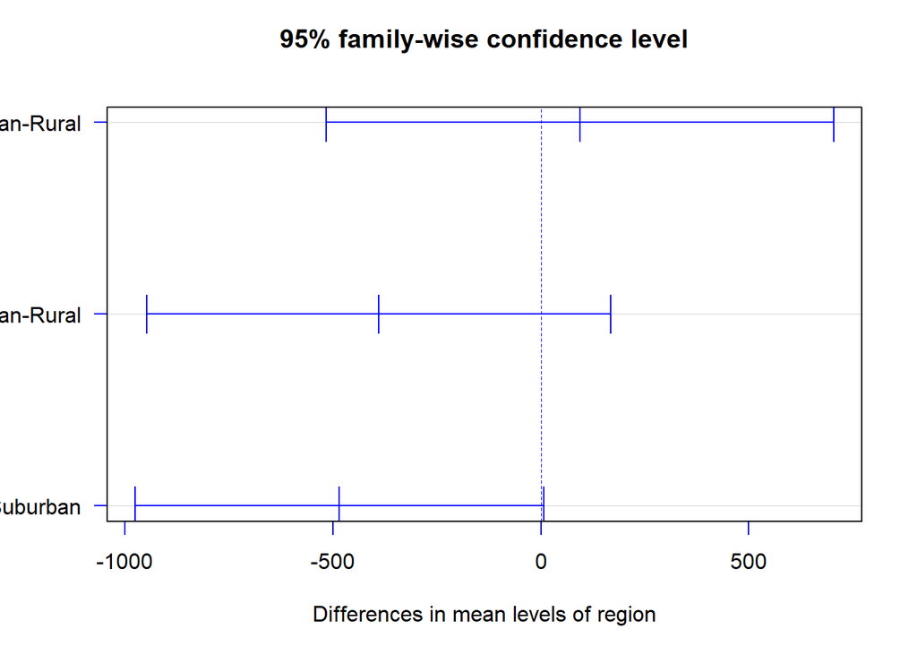

```r
plot(tukey_result, las = 1, col = "blue", )
```

### **Non-Parametric Tests**

#### **Mann-Whitney U Test**

> Assumptions for Mann-Whitney U Test: 1. Independence: The observations in each group (marital statuses) are independent of each other. 2. Ordinal or Continuous Data: The dependent variable (annual spending) should be measured at an ordinal or continuous level. 3. Non-Normal Distribution: The Mann-Whitney U test does not assume normality of the data, making it suitable for non-normally distributed data or when the sample size is small.

##### **State the null and alternative hypotheses**

- Null Hypothesis (H0): There is no significant difference in the median annual spending between different marital statuses since the distibution of the two groups is identical.
- Alternative Hypothesis (H1): There is a significant difference in the median annual spending between different marital statuses since the distribution of the two groups is not identical.

```r
# Mann-Whitney U test for annual_spending by churn
mann_whitney_result <- wilcox.test(annual_spending ~ marital_status, data = data_cleaned)
print(mann_whitney_result)
```

```
    Wilcoxon rank sum test with continuity correction

data:  annual_spending by marital_status
W = 11265850, p-value = 0.3673
alternative hypothesis: true location shift is not equal to 0
```

The results with a p-value of 0.3673 indicate that there is no statistically significant difference in median annual spending between different marital statuses. Therefore, we fail to reject the null hypothesis, suggesting that marital status does not have a significant impact on customers’ annual spending behavior in this dataset.

#### **Kruskal-Wallis Test**

> Assumptions for Kruskal-Wallis Test: 1. Independence: The observations in each group (regions) are independent of each other. 2. Ordinal or Continuous Data: The dependent variable (annual spending) should be measured at an ordinal or continuous level. 3. Non-Normal Distribution: The Kruskal-Wallis test does not assume normality of the data, making it suitable for non-normally distributed data or when the sample size is small.

##### **State the null and alternative hypotheses**

- Null Hypothesis (H0): There is no significant difference in the median annual spending across different regions since the distribution of annual spending is identical across all regions.
- Alternative Hypothesis (H1): There is a significant difference in the median annual spending across different regions since the distribution of annual spending is not identical across all regions.

```r
# Kruskal-Wallis test for annual_spending by region
kruskal_result <- kruskal.test(annual_spending ~ region, data = data_cleaned)
print(kruskal_result)
```

```
    Kruskal-Wallis rank sum test

data:  annual_spending by region
Kruskal-Wallis chi-squared = 5.7116, df = 2, p-value = 0.05751
```

The results with a p-value of 0.0575 indicate that there is no statistically significant difference in median annual spending across different regions at the 5% significance level. Therefore, we fail to reject the null hypothesis, suggesting that regional location does not have a significant impact on customers’ annual spending behavior in this dataset.

#### **Chi-Square Test for Categorical Variables**

> Assumptions for Chi-Square Test: 1. Independence: The observations in the contingency table are independent of each other. 2. Expected Frequency: The expected frequency for each cell in the contingency table should be at least 5 to ensure the validity of the test. 3. Categorical Variables: Both variables being analyzed should be categorical in nature. 4.Sufficient Sample Size: The sample size should be sufficiently large to provide reliable results, typically with at least 20 observations per cell in the contingency table.

##### **State the null and alternative hypotheses**

- Null Hypothesis (H0): There is no association between customer churn and region, meaning that the distribution of churn is the same across all regions.
- Alternative Hypothesis (H1): There is an association between customer churn and region, meaning that the distribution of churn differs across regions.

```r
# Create contingency table for churn and region
contingency_table <- table(data_cleaned$churn, data_cleaned$region)
contingency_table
```

```
      Rural Suburban Urban
  No   1818     2632  4415
  Yes   189      293   504
```

```r
# Perform Chi-Square test
chi_square_result <- chisq.test(contingency_table)
print(chi_square_result)
```

```
    Pearson's Chi-squared test

data:  contingency_table
X-squared = 1.0877, df = 2, p-value = 0.5805
```

The results above with a p-value of 0.5805 indicate that there is no statistically significant association between customer churn and region. Therefore, we fail to reject the null hypothesis, suggesting that the distribution of churn is similar across all regions in this dataset. This implies that regional location does not have a significant impact on customer churn behavior.

## **Phase 6 :Regression Modelling**

### **Simple Linear Regression**

##### **State the null and alternative hypotheses**

- Null Hypothesis (H0): There is no statistically significant effect of annual income on annual spending, meaning that the slope of the regression line is equal to zero.
- Alternative Hypothesis (H1): There is a statistically significant effect of annual income on annual spending, meaning that the slope of the regression line is not equal to zero.

```r
# Simple linear regression for annual_spending by annual_income
model1 <- lm(annual_spending ~ annual_income, data = encoded_data)
summary(model1)
```

```
Call:
lm(formula = annual_spending ~ annual_income, data = encoded_data)

Residuals:
     Min       1Q   Median       3Q      Max
-19027.4  -3262.3   -152.7   3291.5  18042.4

Coefficients:
               Estimate Std. Error t value Pr(>|t|)
(Intercept)   8.054e+02  1.093e+02   7.369 1.86e-13 ***
annual_income 3.285e-01  2.257e-03 145.576  < 2e-16 ***
---
Signif. codes:  0 '***' 0.001 '**' 0.01 '*' 0.05 '.' 0.1 ' ' 1

Residual standard error: 5057 on 9849 degrees of freedom
Multiple R-squared:  0.6827,    Adjusted R-squared:  0.6827
F-statistic: 2.119e+04 on 1 and 9849 DF,  p-value: < 2.2e-16
```

#### **The Equation of the SLR Model**

$$\hat{AnnualSpending} =805.4 + 0.3285 \times AnnualIncome$$
Interpretation: The simple linear regression model indicates that for every one unit increase in annual income, the annual spending is expected to increase by approximately 0.3285 units, holding all else constant. The intercept of 805.4 represents the estimated annual spending when annual income is zero, although this may not be a meaningful value in practice. The model is statistically significant (p-value = 2e-16), suggesting that annual income is a significant predictor of annual spending in this dataset. However, the R-squared value of 0.6827 indicates that approximately 68.27% of the variance in annual spending can be explained by annual income while the adjusted R-squared value of 0.6827 suggests that the model has a good fit to the data, accounting for the number of predictors included in the model. Overall, this simple linear regression model provides valuable insights into the relationship between annual income and annual spending among customers in this dataset.

#### **Residual Diagnostics**

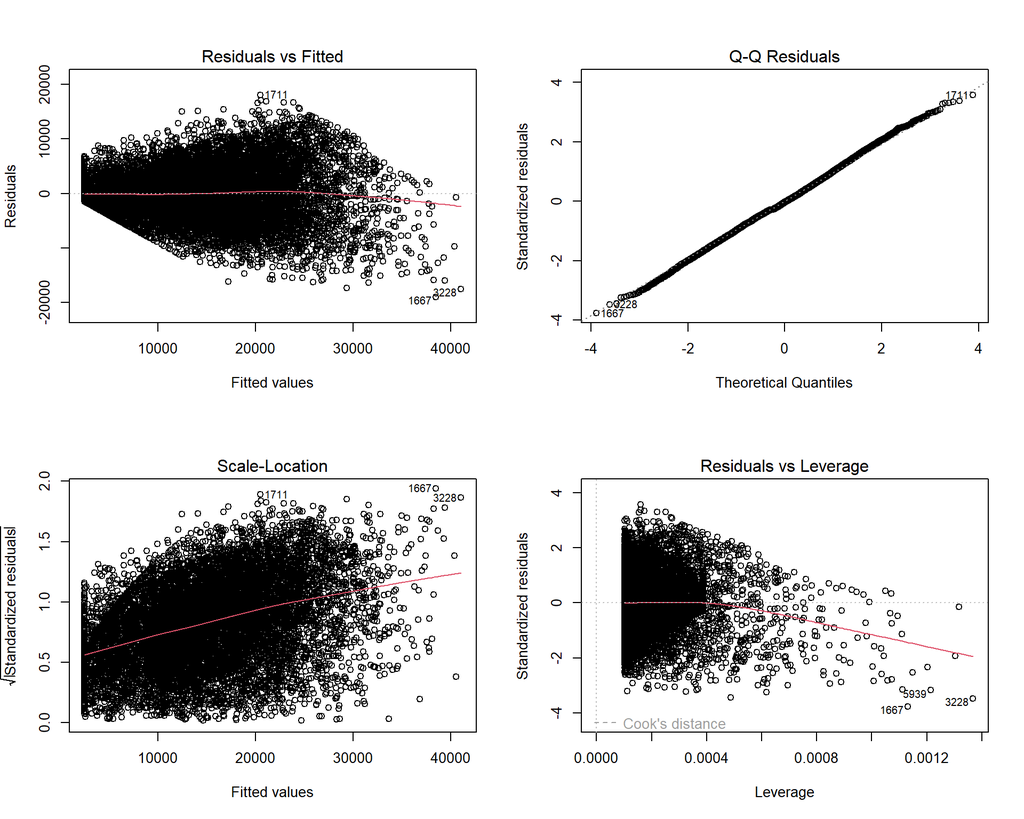

```r
# Generate diagnostic plots
par(mfrow =c(2 ,2))
plot(model1)
```

```r
par(mfrow =c(1 ,1))
```

##### **State the null and alternative hypotheses for linearity**

```r
# Linearity Test
library(car)
linear_test <- linearHypothesis(model1, "annual_income = 0")
print(linear_test)
```

```
Linear hypothesis test:
annual_income = 0

Model 1: restricted model
Model 2: annual_spending ~ annual_income

  Res.Df        RSS Df  Sum of Sq     F    Pr(>F)
1   9850 7.9368e+11
2   9849 2.5182e+11  1 5.4186e+11 21192 < 2.2e-16 ***
---
Signif. codes:  0 '***' 0.001 '**' 0.01 '*' 0.05 '.' 0.1 ' ' 1
```

##### **State the null and alternative hypotheses for normality of residuals**

- Null Hypothesis (H0): The residuals from the regression model are normally distributed.
- Alternative Hypothesis (H1): The residuals from the regression model are not normally distributed.

```r
#Anderson-Darling test for normality of residuals
library(nortest)
ad_test_result <- ad.test(model1$residuals)
print(ad_test_result)
```

```
    Anderson-Darling normality test

data:  model1$residuals
A = 4.7097, p-value = 1.156e-11
```

The results with a p-value of < 0.0001 indicate that we reject the null hypothesis, suggesting that the residuals from the regression model are not normally distributed.

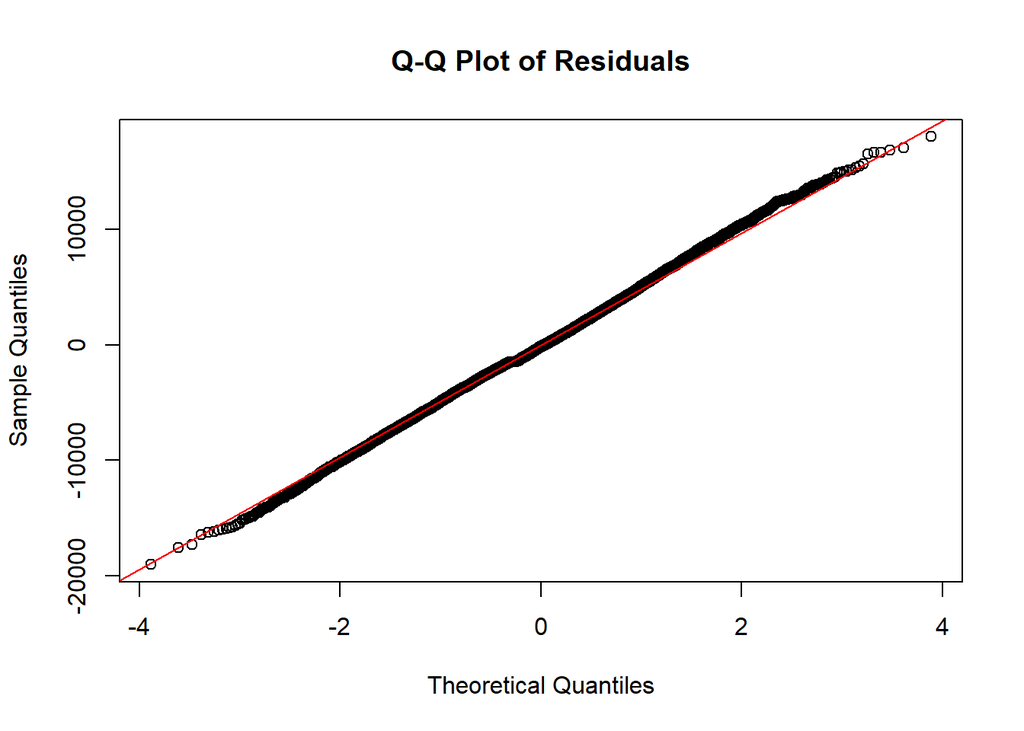

```r
# Normality of Residuals
qqnorm(model1$residuals, main = "Q-Q Plot of Residuals")
qqline(model1$residuals, col = "red")
```

##### **State the null and alternative hypotheses for homoscedasticity**

- Null Hypothesis (H0): The residuals from the regression model have constant variance
- Alternative Hypothesis (H1): The residuals from the regression model do not have constant variance, meaning that there is heteroscedasticity in the residuals.

```r
# Breusch-Pagan test for homoscedasticity
library(lmtest)
bp_test_result <- bptest(model1)
print(bp_test_result)
```

```
    studentized Breusch-Pagan test

data:  model1
BP = 1516.2, df = 1, p-value < 2.2e-16
```

The results with a p-value of < 0.05 indicate that we reject the null hypothesis, suggesting that there is heteroscedasticity in the residuals of the regression model, meaning that the variance of the residuals is not constant across all levels of the independent variable (annual income).

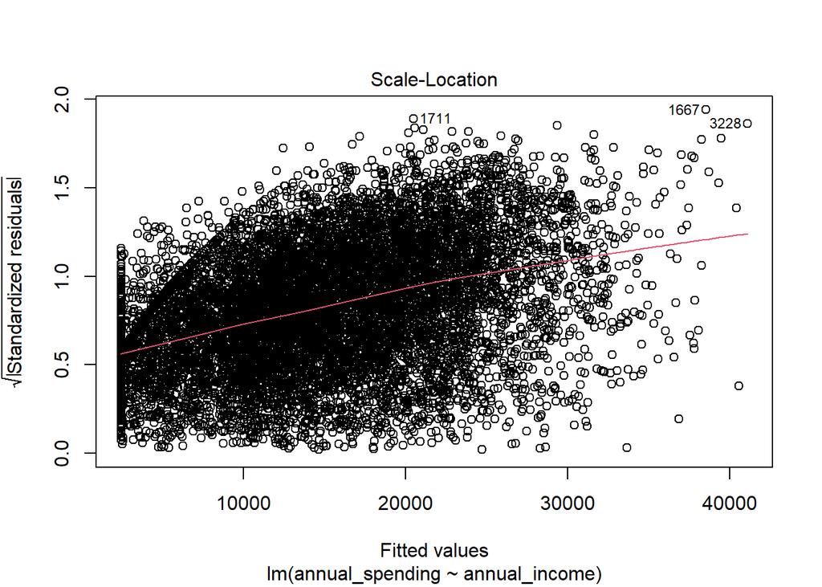

```r
# Homoscedasticity
plot(model1,which=3 )
```

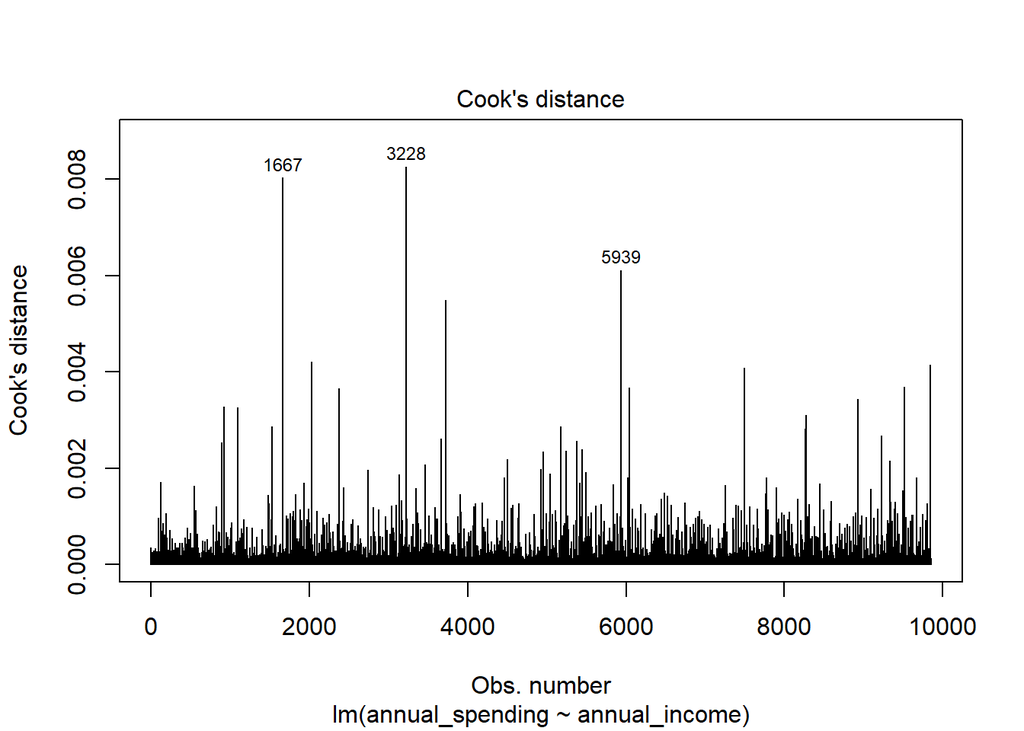

```r
# Outliers and Influential Points
plot(model1, which = 4)
```

### **Multiple Linear Regression**

```r
model2 <- lm(annual_spending ~ annual_income + credit_score + loyalty_years + age + region + employment_status + online_shopper, data = data_cleaned)
summary(model2)
```

```
Call:
lm(formula = annual_spending ~ annual_income + credit_score +
    loyalty_years + age + region + employment_status + online_shopper,
    data = data_cleaned)

Residuals:
     Min       1Q   Median       3Q      Max
-18824.5  -3273.9   -154.2   3292.0  18030.1

Coefficients:
                                 Estimate Std. Error t value Pr(>|t|)
(Intercept)                     1.065e+03  6.783e+02   1.571    0.116
annual_income                   3.289e-01  4.594e-03  71.583   <2e-16 ***
credit_score                   -1.484e+00  1.723e+00  -0.862    0.389
loyalty_years                  -2.566e+00  1.792e+01  -0.143    0.886
age                             1.053e+01  1.782e+01   0.591    0.555
regionSuburban                  9.496e+01  1.467e+02   0.647    0.517
regionUrban                     5.281e+01  1.349e+02   0.392    0.695
employment_statusSelf-Employed -6.278e+01  1.358e+02  -0.462    0.644
employment_statusStudent       -2.618e+02  2.062e+02  -1.270    0.204
employment_statusUnemployed    -2.290e+02  2.018e+02  -1.135    0.257
online_shopperYes               1.070e+02  1.043e+02   1.026    0.305
---
Signif. codes:  0 '***' 0.001 '**' 0.01 '*' 0.05 '.' 0.1 ' ' 1

Residual standard error: 5057 on 9840 degrees of freedom
Multiple R-squared:  0.6829,    Adjusted R-squared:  0.6826
F-statistic:  2119 on 10 and 9840 DF,  p-value: < 2.2e-16
```

Interpretation: The multiple linear regression model indicates that only annual income is a statistically significant predictor of annual spending (p-value < 0.001), while credit score, loyalty years, age, region, employment status, and online shopper status do not have a statistically significant effect on annual spending (p-values > 0.05). The coefficient for annual income suggests that for every one unit increase in annual income, the annual spending is expected to increase by approximately 0.3289 units, holding all other variables constant. The R-squared value of 0.6829 indicates that approximately 68.29% of the variance in annual spending can be explained by the independent variables included in the model, while the adjusted R-squared value of 0.6826 suggests that 68.26% of the variance in annual spending can be explained by annual income,credit score, loyalty years, age, region, employment status, and online shopper status, after adjusting for the number of predictors in the model. Overall, this multiple linear regression model provides insights into the factors influencing annual spending among customers in this dataset, with annual income being the most significant predictor.

### **Checking for Multicollinearity**

```r
library(car)
vif(model2)
```

```
                       GVIF Df GVIF^(1/(2*Df))
annual_income      4.143930  1        2.035664
credit_score       3.819963  1        1.954472
loyalty_years     15.335849  1        3.916101
age               15.945673  1        3.993203
region             1.029513  2        1.007298
employment_status  1.859912  3        1.108959
online_shopper     1.042344  1        1.020953
```